# Task 4

Evgeny Bakin

2024-01-01

# Сравнение вероятностей наступления события в двухгрупповом исследовании

## 1. Модель пациента

```r
p_R <- 0.1 # Истинная вероятность выздоровления для референса (в ГЕНЕРАЛЬНОЙ СОВОКУПНОСТИ)

p_T <- 0.2 # Истинная вероятность выздоровления для теста (в ГЕНЕРАЛЬНОЙ СОВОКУПНОСТИ)

true_OR <- (p_T/(1-p_T))/(p_R/(1-p_R)) # Истинное отношение шансов
```

## 2. Генерация однократной выборки

```r
sample_size <- 100 # Количество пациентов в каждой из групп

df_trial <- data.frame(
  arm = rep(c('R', 'T'), each = sample_size),
  patient_ID = rep(1:sample_size, 2),
  recovery_status = c(sample(c(1,0), sample_size, replace = TRUE, prob = c(p_R, 1 - p_R)),
                      sample(c(1,0), sample_size, replace = TRUE, prob = c(p_T, 1 - p_T)))
)
```

## 3. Построение ДИ для разницы вероятностей

```r
df_prop <- df_trial %>%
  group_by(arm) %>% # Группировка типу интервенции (тест/референс)
  dplyr::summarise(x = sum(recovery_status), # Подсчет числа положительных исходов (единиц)
                   n = n()) %>% # Подсчет общего числа пациентов в группе
  ungroup() %>%
  dplyr::summarise(X = list(x), N = list(n)) %>% # Соединение все x и n в отдельные вектора
  rowwise() %>%
  mutate(tst = list(broom::tidy(prop.test(X, N)))) %>% # Вычисление ДИ на разницу пропорций
  unnest(tst) %>% # Раскладка результатов prop.test по столбцам
  mutate(catch = ifelse(conf.low < p_R-p_T & p_R-p_T < conf.high, "Catch", "Miss"))

print(df_prop)
```

```
## # A tibble: 1 × 12
##   X     N     estimate1 estimate2 statistic p.value parameter conf.low conf.high
##   <lis> <lis>     <dbl>     <dbl>     <dbl>   <dbl>     <dbl>    <dbl>     <dbl>
## 1 <dbl> <int>      0.08      0.21      5.81  0.0160         1   -0.236   -0.0241
## # ℹ 3 more variables: method <chr>, alternative <chr>, catch <chr>
```

## ЗАДАНИЕ №1

- Повторить этот эксперимент 1000 раз, каждый раз фиксируя факт накрытия истинной разницы в вероятностях (p_R-p_T).
- Оценить полученную вероятность накрытия с заданной по умолчанию (0.95).
- Построить гистограмму точечной оценки разницы вероятностей (estimate1-estimate2) и подумать о ее распределении.

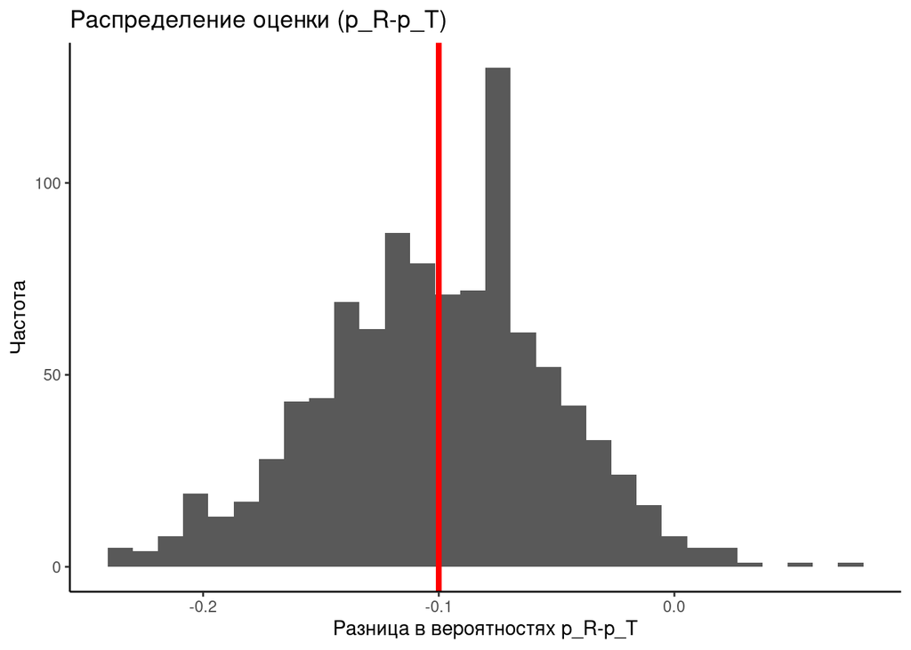

```r
n_sims <- 1000

coverage_count <- 0
estimates_diff <- numeric(n_sims)

for (i in 1:n_sims) {
  set.seed(i)
  df_trial <- data.frame(
    arm = rep(c('R', 'T'), each = sample_size),
    patient_ID = rep(1:sample_size, 2),
    recovery_status = c(sample(c(1,0), sample_size, replace = TRUE, prob = c(p_R, 1 - p_R)),
                        sample(c(1,0), sample_size, replace = TRUE, prob = c(p_T, 1 - p_T)))
  )


  df_prop <- df_trial %>%
    group_by(arm) %>% # Группировка типу интервенции (тест/референс)
    dplyr::summarise(x = sum(recovery_status), # Подсчет числа положительных исходов (единиц)
                     n = n()) %>% # Подсчет общего числа пациентов в группе
    ungroup() %>%
    dplyr::summarise(X = list(x), N = list(n)) %>% # Соединение все x и n в отдельные вектора
    rowwise() %>%
    mutate(tst = list(broom::tidy(prop.test(X, N)))) %>% # Вычисление ДИ на разницу пропорций
    unnest(tst) %>% # Раскладка результатов prop.test по столбцам
    mutate(catch = ifelse(conf.low < p_R-p_T & p_R-p_T < conf.high, "Catch", "Miss"))

  # Попадает ли истинная разница в интервал?
  catch <- any(df_prop$catch == "Catch")
  coverage_count <- coverage_count + catch
  diff_estimate <- df_prop$estimate1 - df_prop$estimate2
  estimates_diff[i] <- diff_estimate
}

# Вероятность накрытия
coverage_prob <- coverage_count / n_sims

# Гистограмма
ggplot(data.frame(estimates_diff), aes(x = estimates_diff)) +
  geom_histogram() +
  labs(title = "Распределение оценки (p_R-p_T)", x = "Разница в вероятностях p_R-p_T", y = "Частота")+ geom_vline(xintercept = p_R-p_T,color = "red", size=1.5)+theme_classic()
```

```r
print(paste("Вероятность накрытия:", coverage_prob))
```

```
## [1] "Вероятность накрытия: 0.968"
```

Выводы: вероятность накрытия выше заданной по умолчанию (0.95), т.е. истинная разница чаще оказывается в интервале, чем мы бы ожидали. Это делает оценку консервативной, это может быть хорошо (если мы хотим уменьшить риск ошибочных выводов), но может быть и плохо (т.к. такой интервал чуть менее информативен), и возможно это может измениться в зависимости от заданных параметров. Что касается гистограммы, мода находится в отрицательном диапазоне, что мы бы ожидали, зная реальную разницу (-0.1). Конкретно с этими сидами есть высокий пик, но когда я крутила эксперименты без сида, он мог появляться или нет, так что думаю, это какая-то флуктуация. Само распределение похоже на нормальное, оно симметричое относительно центра и у него не очень широкие концы, что для нас хорошо.

- Проверить, корректно ли работает методика построения ДИ, реализованная в prop.test, при различных значениях p_R и p_T.

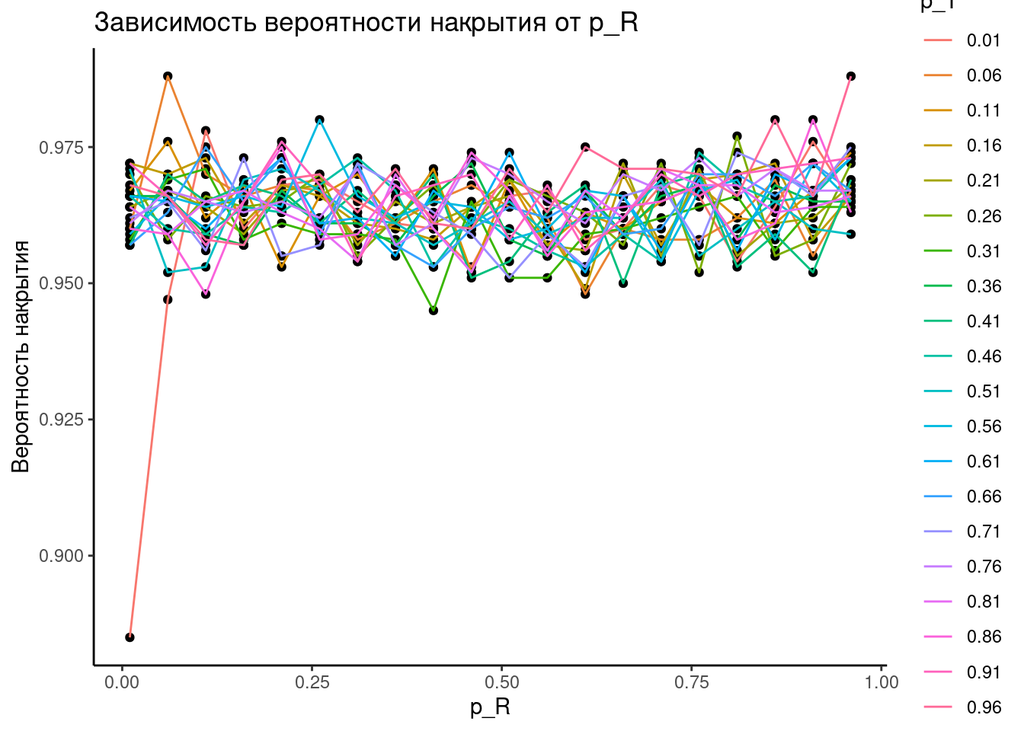

```r
set.seed(2024)
p_R_range <- seq(0.01, 0.99, by = 0.05)
p_T_range <- seq(0.01, 0.99, by = 0.05)

coverage_results <- data.frame(p_R = numeric(), p_T = numeric(), coverage_prob = numeric())

for (p_R in p_R_range) {
  for (p_T in p_T_range) {
    coverage_count <- 0
    for (i in 1:n_sims) {
      # с датафреймами считалось слишком долго, так что попыталась переписать
      recovery_R <- sample(c(1, 0), sample_size, replace = TRUE, prob = c(p_R, 1 - p_R))
      recovery_T <- sample(c(1, 0), sample_size, replace = TRUE, prob = c(p_T, 1 - p_T))
      x <- c(sum(recovery_R), sum(recovery_T))
      n <- c(sample_size, sample_size)
      test_result <- prop.test(x, n)
      conf.int <- test_result$conf.int
      if (conf.int[1] < p_R - p_T && p_R - p_T < conf.int[2]) {
        coverage_count <- coverage_count + 1
      }
    }

    coverage_prob <- coverage_count / n_sims
    coverage_results <- rbind(coverage_results, data.frame(p_R = p_R, p_T = p_T, coverage_prob = coverage_prob))
  }
}

ggplot(coverage_results, aes(x = p_R, y = coverage_prob)) +
  geom_point() +
  geom_line(aes(group = p_T, color = as.factor(p_T))) +
  labs(title = "Зависимость вероятности накрытия от p_R", x = "p_R", y = "Вероятность накрытия", color = "p_T") +
  theme_classic()
```

Вывод: 0.95 это редкое значение при разных p_R и p_T. В случае значения 0.01 для p_T и p_R функция сильно ошибается и вероятность накрытия становится сильно меньше ожидаемой (в районе 88%). Иногда оценка чуть меньше 0.95, но это скорее исключение, в основном оценки консервативные. эта визуализация не очень наглядная, поэтому попробую побиннить оценки и возможно выводы изменятся.

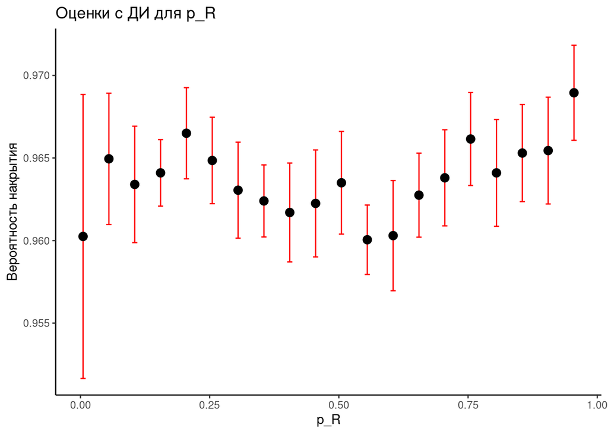

```r
coverage_results$bins <- cut(coverage_results$p_R, breaks = seq(0, 1, by = 0.05))
coverage_summary <- coverage_results %>%
  group_by(bins) %>%
  summarise(
    mean = mean(coverage_prob),
    sd = sd(coverage_prob),
    se = sd / sqrt(n()),
    ci_lower = mean - qt(0.975, df = n() - 1) * se,
    ci_upper = mean + qt(0.975, df = n() - 1) * se
  ) %>%
  mutate(bins_mid = as.numeric(gsub(".*\\((.+)\\,.+", "\\1", bins)) + 0.01 / 2)

ggplot(coverage_results, aes(x = p_R)) +
  geom_errorbar(data = coverage_summary, aes(x = bins_mid, ymin = ci_lower, ymax = ci_upper), width = 0.01, color = 'red') +
  geom_point(data = coverage_summary, aes(x = bins_mid, y = mean), color = 'black', size = 3) +
  labs(title = 'Оценки с ДИ для p_R', x = 'p_R', y = 'Вероятность накрытия')+theme_classic()
```

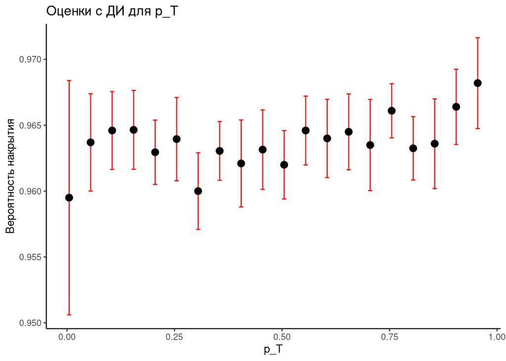

```r
coverage_results$bins <- cut(coverage_results$p_T, breaks = seq(0, 1, by = 0.05))
coverage_summary <- coverage_results %>%
  group_by(bins) %>%
  summarise(
    mean = mean(coverage_prob),
    sd = sd(coverage_prob),
    se = sd / sqrt(n()),
    ci_lower = mean - qt(0.975, df = n() - 1) * se,
    ci_upper = mean + qt(0.975, df = n() - 1) * se
  ) %>%
  mutate(bins_mid = as.numeric(gsub(".*\\((.+)\\,.+", "\\1", bins)) + 0.01 / 2)

ggplot(coverage_results, aes(x = p_T)) +
  geom_errorbar(data = coverage_summary, aes(x = bins_mid, ymin = ci_lower, ymax = ci_upper), width = 0.01, color = 'red') +
  geom_point(data = coverage_summary, aes(x = bins_mid, y = mean), color = 'black', size = 3) +
  labs(title = 'Оценки с ДИ для p_T', x = 'p_T', y = 'Вероятность накрытия')+theme_classic()
```

То же можно сказать для p_T, видимо наш вывод для изначальных значения p_T и p_R подтверждается и для других значений. Оценка теста консервативная и выше заданной, это может отвечать нашим требованиям или нет, зависит от наших целей.

## 4. Построение ДИ для отношения шансов

```r
# На всякий случай перезадам df_trial, как в примере

p_R <- 0.1 # Истинная вероятность выздоровления для референса (в ГЕНЕРАЛЬНОЙ СОВОКУПНОСТИ)
p_T <- 0.2 # Истинная вероятность выздоровления для теста (в ГЕНЕРАЛЬНОЙ СОВОКУПНОСТИ)
true_OR <- (p_T/(1-p_T))/(p_R/(1-p_R)) # Истинное отношение шансов
sample_size <- 100 # Количество пациентов в каждой из групп

df_trial <- data.frame(
  arm = rep(c('R', 'T'), each = sample_size),
  patient_ID = rep(1:sample_size, 2),
  recovery_status = c(sample(c(1,0), sample_size, replace = TRUE, prob = c(p_R, 1 - p_R)),
                      sample(c(1,0), sample_size, replace = TRUE, prob = c(p_T, 1 - p_T)))
)

df_OR <- df_trial %>%
  dplyr::summarise(broom::tidy(fisher.test(table(.$arm, .$recovery_status)))) %>%
  mutate(catch = ifelse(conf.low < true_OR & true_OR < conf.high, "Catch", "Miss"))

print(df_OR)
```

```
##   estimate   p.value  conf.low conf.high                             method
## 1 1.393235 0.4667101 0.6406519  3.079663 Fisher's Exact Test for Count Data
##   alternative catch
## 1   two.sided Catch
```

## ЗАДАНИЕ №2

- Повторить этот эксперимент 1000 раз, каждый раз фиксируя факт накрытия истинного отношения шансов (true_OR).
- Оценить полученную вероятность накрытия с заданной по умолчанию (0.95).
- Построить гистограмму точечной оценки отношения шансов (estimate) и подумать о ее распределении.

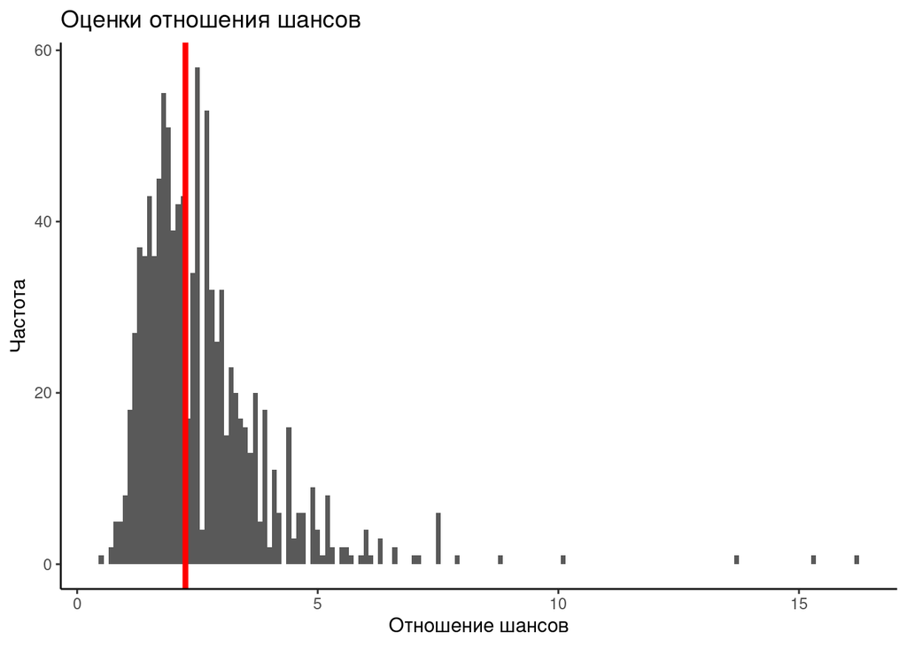

```r
n_sims <- 1000
coverage_count <- 0
or_estimates <- numeric(n_sims)

for (i in 1:n_sims) {
  set.seed(i)
  recovery_R <- sample(c(1,0), sample_size, replace = TRUE, prob = c(p_R, 1 - p_R))
  recovery_T <- sample(c(1,0), sample_size, replace = TRUE, prob = c(p_T, 1 - p_T))
  df_trial <- data.frame(
    arm = rep(c('R', 'T'), each = sample_size),
    recovery_status = c(recovery_R, recovery_T)
  )
  fisher_test_result <- fisher.test(table(df_trial$arm, df_trial$recovery_status))

  conf.int <- fisher_test_result$conf.int
  or_estimate <- fisher_test_result$estimate
  if (conf.int[1] < true_OR && true_OR < conf.int[2]) {
    coverage_count <- coverage_count + 1
  }
  or_estimates[i] <- or_estimate
}

coverage_prob <- coverage_count / n_sims
or_estimates = data.frame(or_estimate = or_estimates)
ggplot(or_estimates, aes(x = or_estimate)) +
  geom_histogram(binwidth = 0.1)+ geom_vline(xintercept = true_OR,color = "red", size=1.5) +
  labs(title = "Оценки отношения шансов", x = "Отношение шансов", y = "Частота") +
  theme_classic()
```

```r
# Вывод вероятности накрытия
print(paste("Вероятность накрытия:", coverage_prob))
```

```
## [1] "Вероятность накрытия: 0.971"
```

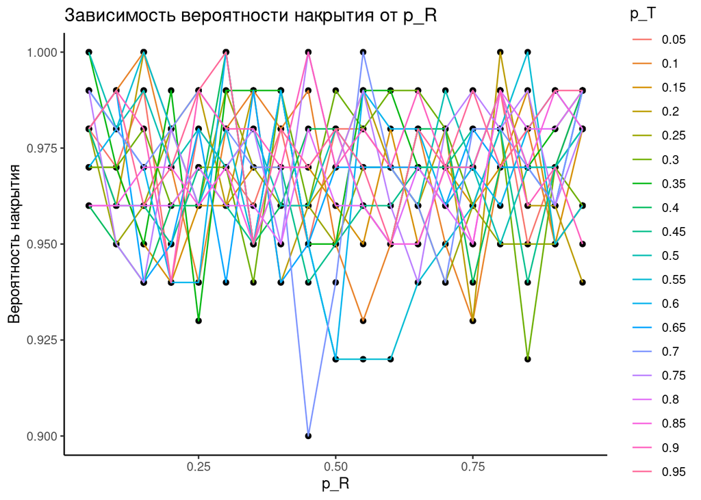

```r
n_sims = 100 # делаю меньше симуляций, т.к. считается слишком долго
set.seed(2024)
p_R_range <- seq(0.05, 0.99, by = 0.05)
p_T_range <- seq(0.05, 0.99, by = 0.05)

coverage_results <- data.frame(p_R = numeric(), p_T = numeric(), coverage_prob = numeric())

for (p_R in p_R_range) {
  for (p_T in p_T_range) {
    coverage_count <- 0
    true_OR <- (p_T/(1-p_T))/(p_R/(1-p_R))
    for (i in 1:n_sims) {

      recovery_R <- sample(c(1,0), sample_size, replace = TRUE, prob = c(p_R, 1 - p_R))
      recovery_T <- sample(c(1,0), sample_size, replace = TRUE, prob = c(p_T, 1 - p_T))

      df_trial <- data.frame(
        arm = rep(c('R', 'T'), each = sample_size),
        recovery_status = c(recovery_R, recovery_T)
      )

      fisher_test_result <- fisher.test(table(df_trial$arm, df_trial$recovery_status))

      conf.int <- fisher_test_result$conf.int
      if (conf.int[1] < true_OR && true_OR < conf.int[2]) {
        coverage_count <- coverage_count + 1
      }
    }

    coverage_prob <- coverage_count / n_sims
    coverage_results <- rbind(coverage_results, data.frame(p_R = p_R, p_T = p_T, coverage_prob = coverage_prob))
  }
}

ggplot(coverage_results, aes(x = p_R, y = coverage_prob)) +
  geom_point() +
  geom_line(aes(group = p_T, color = as.factor(p_T))) +
  labs(title = "Зависимость вероятности накрытия от p_R", x = "p_R", y = "Вероятность накрытия", color = "p_T") +
  theme_classic()
```

Какой-то очевидной линейной зависимости снова не видно, но визуально кажется, что ошибки для оценок здесь гораздо чаще: оценка ниже 0.95 встречается чаще и не сказать, что это строго коррелирует с p_T или p_R.

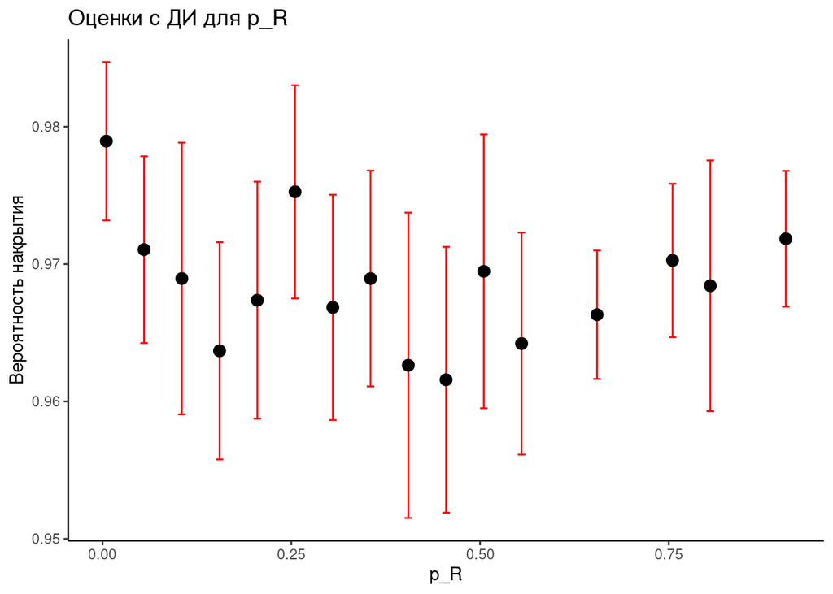

```r
coverage_results$bins <- cut(coverage_results$p_R, breaks = seq(0, 1, by = 0.05))
coverage_summary <- coverage_results %>%
  group_by(bins) %>%
  summarise(
    mean = mean(coverage_prob),
    sd = sd(coverage_prob),
    se = sd / sqrt(n()),
    ci_lower = mean - qt(0.975, df = n() - 1) * se,
    ci_upper = mean + qt(0.975, df = n() - 1) * se
  ) %>%
  mutate(bins_mid = as.numeric(gsub(".*\\((.+)\\,.+", "\\1", bins)) + 0.01 / 2)

ggplot(coverage_results, aes(x = p_R)) +
  geom_errorbar(data = coverage_summary, aes(x = bins_mid, ymin = ci_lower, ymax = ci_upper), width = 0.01, color = 'red') +
  geom_point(data = coverage_summary, aes(x = bins_mid, y = mean), color = 'black', size = 3) +
  labs(title = 'Оценки с ДИ для p_R', x = 'p_R', y = 'Вероятность накрытия')+theme_classic()
```

Если мы усредняем оценки по бинам, то в целом все не так плохо, все средние выше 0.95, какого-то очевидного роста или падения вероятности накрытия интервалов, как мне кажется, нет.

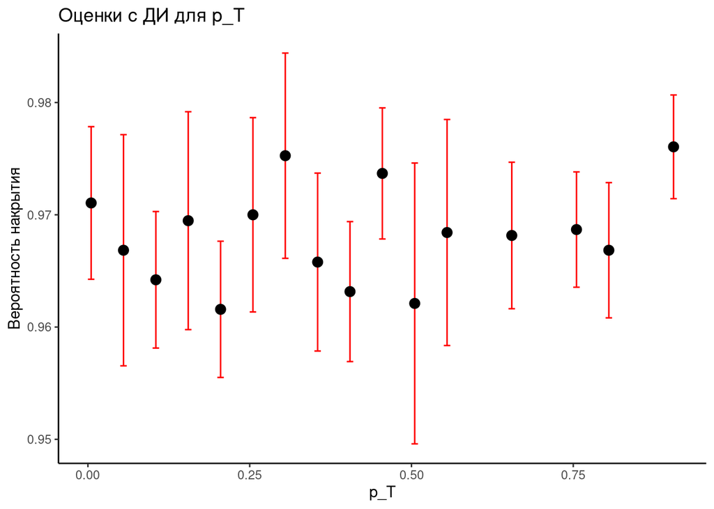

```r
coverage_results$bins <- cut(coverage_results$p_T, breaks = seq(0, 1, by = 0.05))
coverage_summary <- coverage_results %>%
  group_by(bins) %>%
  summarise(
    mean = mean(coverage_prob),
    sd = sd(coverage_prob),
    se = sd / sqrt(n()),
    ci_lower = mean - qt(0.975, df = n() - 1) * se,
    ci_upper = mean + qt(0.975, df = n() - 1) * se
  ) %>%
  mutate(bins_mid = as.numeric(gsub(".*\\((.+)\\,.+", "\\1", bins)) + 0.01 / 2)

ggplot(coverage_results, aes(x = p_T)) +
  geom_errorbar(data = coverage_summary, aes(x = bins_mid, ymin = ci_lower, ymax = ci_upper), width = 0.01, color = 'red') +
  geom_point(data = coverage_summary, aes(x = bins_mid, y = mean), color = 'black', size = 3) +
  labs(title = 'Оценки с ДИ для p_T', x = 'p_T', y = 'Вероятность накрытия')+theme_classic()
```